# A Macroeconomics Dashboard on Turkey Inflation

Enes Gencer

31-03-2022

Inflation is a hot topic for both global and Turkish macroeconomics nowadays. Inspired by Rami Krispin and reverse engineering his U.S. Electricity dashboard, I created a dashboard for Turkey’s macroeconomics. You can find a one-month ahead inflation forecast, key monthly macroeconomic variables, and seasonality analyses.

The data and machine learning pipelines are automated via Docker, Github Actions, and Rmarkdown. The dashboard has too many dimensions to cover in a single blog post since I experimented with different aspects. As a result, in this blog post, I focus on the underlying economics and the forecasting method I choose, Elastic Net. In the coming blog posts, I might write on different aspects like flexdashboard, Docker, or a more interesting forecasting method like LSTM using Keras on R.

## Getting Started

First, we load the required libraries and data set.

```r
library(tidyverse)
library(lubridate)
library(caret)
library(zoo)
library(ggthemes)

load("~/turkey-macro-dashboard/processed_data/processed_data.Rdata")
```

## Dataset

The data set consists of monthly macroeconomic variables. The dependent variable is the Y-o-Y change in CPI, and the independent variables are lags of

- Price indexes
- Tendency surveys of the economic agents
- Production statistics
- Balance of payments statistics
- Exchange rate return
- Month (to take into account seasonality)
- CPI_Forecast of TBATS model

I only included lags to avoid hindsight bias or the “knew-it-all-along” phenomenon. Second, the analysis does not cover the effect of interest rates on inflation. That is only because I have a pre-written script to pull monthly variables. Therefore, I do not want to spend time adjusting the frequency, and the effect of the interest rate is known anyway.

```r
forecast_date = as.Date(as.yearmon(today())) + months(1) - days(1)

train_data <- forecast_df %>%
  filter(Date < forecast_date)

test_data <- forecast_df %>%
  filter(Date  == forecast_date)

tail(train_data,3)
```

```
## # A tibble: 3 x 94
##   Date         CPI CPI_Lag1 CLI_Lag1 Domestic_PPI_Lag1 Inflation_Expectation_La~
##   <date>     <dbl>    <dbl>    <dbl>             <dbl>                     <dbl>
## 1 2021-12-31 0.361    0.213     102.             0.546                      15.6
## 2 2022-01-31 0.487    0.361     102.             0.799                      21.4
## 3 2022-02-28 0.544    0.487     101.             0.935                      25.4
## # ... with 88 more variables: FS_Confidience_Lag1 <dbl>,
## #   RS_Confidience_Lag1 <dbl>, Production_Volume_Lag1 <dbl>,
## #   Export_Orders_Lag1 <dbl>, BoP_Lag1 <dbl>, Utilization_Rate_Lag1 <dbl>,
## #   Consumer_Confidience_Lag1 <dbl>, Import_Annual_Ret_Lag1 <dbl>,
## #   Import_Monthly_Ret_Lag1 <dbl>, UsdTry_Annual_Ret_Lag1 <dbl>,
## #   UsdTry_Monthly_Ret_Lag1 <dbl>, CPI_Lag2 <dbl>, CLI_Lag2 <dbl>,
## #   Domestic_PPI_Lag2 <dbl>, Inflation_Expectation_Lag2 <dbl>, ...
```

```r
head(test_data)
```

```
## # A tibble: 1 x 94
##   Date         CPI CPI_Lag1 CLI_Lag1 Domestic_PPI_Lag1 Inflation_Expectation_La~
##   <date>     <dbl>    <dbl>    <dbl>             <dbl>                     <dbl>
## 1 2022-03-31    NA    0.544     101.              1.05                      24.8
## # ... with 88 more variables: FS_Confidience_Lag1 <dbl>,
## #   RS_Confidience_Lag1 <dbl>, Production_Volume_Lag1 <dbl>,
## #   Export_Orders_Lag1 <dbl>, BoP_Lag1 <dbl>, Utilization_Rate_Lag1 <dbl>,
## #   Consumer_Confidience_Lag1 <dbl>, Import_Annual_Ret_Lag1 <dbl>,
## #   Import_Monthly_Ret_Lag1 <dbl>, UsdTry_Annual_Ret_Lag1 <dbl>,
## #   UsdTry_Monthly_Ret_Lag1 <dbl>, CPI_Lag2 <dbl>, CLI_Lag2 <dbl>,
## #   Domestic_PPI_Lag2 <dbl>, Inflation_Expectation_Lag2 <dbl>, ...
```

## Modelling

I use time-series cross-validation to tune the hyper-parameters and evaluate the performance. To learn more details on time-series cross-validation, please visit: https://robjhyndman.com/hyndsight/tscv/

I use a fixed window size. The idea is that the inflation dynamics might evolve over time. For instance, we have observed the increasing effect of the exchange rate on inflation in recent years. However, as a result of the commodity super-cycle, we might see the producer price index come into play. Therefore, a more dynamic modelling structure is ensured by fixed window size.

```r
# Construct time slices for time-series cross validation

time_slices <- trainControl(
  method = "timeslice",
  initialWindow = 36,
  fixedWindow = TRUE,
  horizon = 3,
  savePredictions = TRUE,
  verboseIter = FALSE
)
```

Elastic net is a regularized regression technique that linearly combines L_1 and L_2 penalties. In other words, it is a combination of LASSO and Ridge regressions. Elastic net regularization has several advantages in my case. First, there is a very high correlation between the explanatory variables. Notice that I included multiple lags of a given variable. Also, given two different variables might have associations through several channels. Hence, multi-collinearity should be considered. Second, I desire an interpretable model. Third, in my case, it has higher performance (in terms of RMSE and MAPE) compared to more complex models like Random Forest or xgBoost. Considering the advantages I mentioned, detecting sparse variables and shrinking the remaining coefficients make perfect sense.

```r
# Train the model

elastic_net_fit <- train(
  CPI ~ .,
  data = train_data[,-1],
  na.action = "na.pass",
  method = "glmnet",
  preProcess = c("center", "scale"),
  trControl = time_slices
)
```

## Results

First, I get the best hyper parameters and collect the predictions of the selected model.

```r
# Choose the best regularization parameters

best_alpha = elastic_net_fit$bestTune[1] %>% pull
best_alpha
```

```
## [1] 0.55
```

```r
best_lambda = elastic_net_fit$bestTune[2] %>% pull
best_lambda
```

```
## [1] 0.004655752
```

```r
lasso_preds <- elastic_net_fit$pred %>%
  filter(alpha == best_alpha,
         lambda == best_lambda)

# Collect predictions

get_predictions <- function(x){
  x1 <- x %>%
    filter(!Resample == unique(Resample)[length(unique(Resample))]) %>%
    group_by(Resample) %>%
    filter(rowIndex == min(rowIndex)) %>%
    ungroup() %>%
    select(rowIndex,pred, obs) %>%
    rename(CPI = obs) %>%
    left_join(forecast_df %>% select(Date, CPI), by = "CPI") %>%
    select(Date, CPI, pred)

  x2 <- x %>%
    filter(Resample == unique(Resample)[length(unique(Resample))]) %>%
    select(rowIndex,pred, obs) %>%
    rename(CPI = obs) %>%
    left_join(forecast_df %>% select(Date, CPI), by = "CPI") %>%
    select(Date, CPI, pred)

  res <- bind_rows(x1, x2)
  res
}

lasso_preds = get_predictions(lasso_preds)
lasso_test <- tibble(Date = test_data$Date,
                     pred = predict(elastic_net_fit,
                                    test_data))
lasso_preds <- bind_rows(lasso_preds, lasso_test)
```

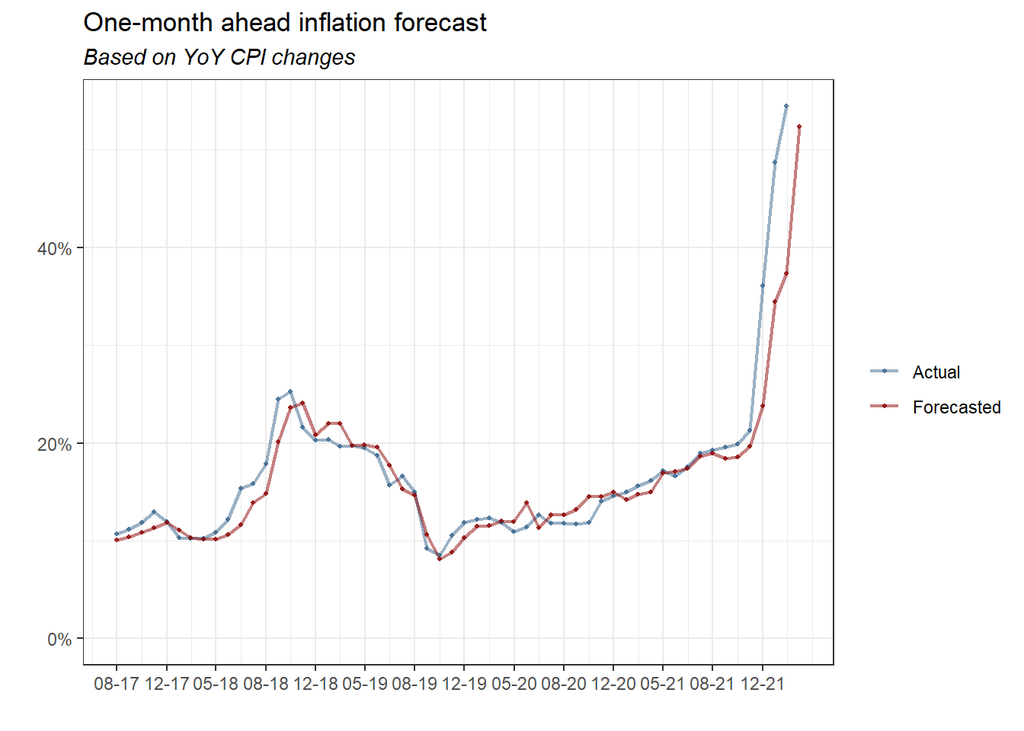

```r
# Visualize results

lasso_preds %>%
  rename(Actual = CPI,
         Forecasted = pred) %>%
  gather(key = "Variable", value = "Value", Actual:Forecasted) %>%
  ggplot(aes(x = Date, y = Value, color = Variable))+
  geom_line(size = 0.75, alpha = 0.5)+
  geom_point(size = 0.75, alpha = 0.75)+
  scale_color_manual(values = c("steelblue4", "darkred"))+
  theme_bw()+
  scale_y_continuous(labels = scales::percent)+
  scale_x_date(breaks = seq(min(lasso_preds$Date),
                            max(lasso_preds$Date),
                            by="4 months"),
             date_labels = '%m-%y')+
  labs(x = "",
       y = "",
       subtitle = "Based on YoY CPI changes",
       title = "One-month ahead inflation forecast",
       color = "")+
  expand_limits(y = 0)+
  theme(plot.subtitle = element_text(face = "italic"))
```

The plot shows a one-month ahead inflation forecast and actual inflation based on the YoY CPI changes.

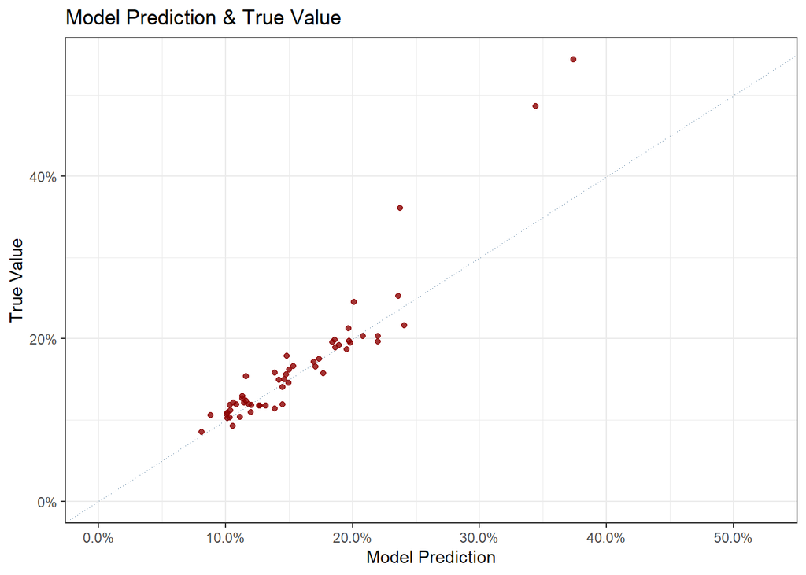

```r
lasso_preds %>%
  ggplot(aes(x = pred, y = CPI))+
  geom_point(size = 1.5, alpha = 0.8, color = "darkred")+
  geom_abline(intercept = 0,
              slope = 1,
              size = 0.3,
              linetype = 3,
              alpha = 0.8,
              color = "steelblue4")+
  theme_bw()+
  scale_y_continuous(labels = scales::percent)+
  scale_x_continuous(labels = scales::percent)+
  expand_limits(y = 0, x = 0)+
  labs(title = "Model Prediction & True Value",
       x = "Model Prediction",
       y = "True Value")
```

The second plot shows the predictions vs. the real values. You would expect to see the points are piled up around the 45-degree line. The model seems consistent in its predictions except for the three outliers, which will become sounder in the following plot.

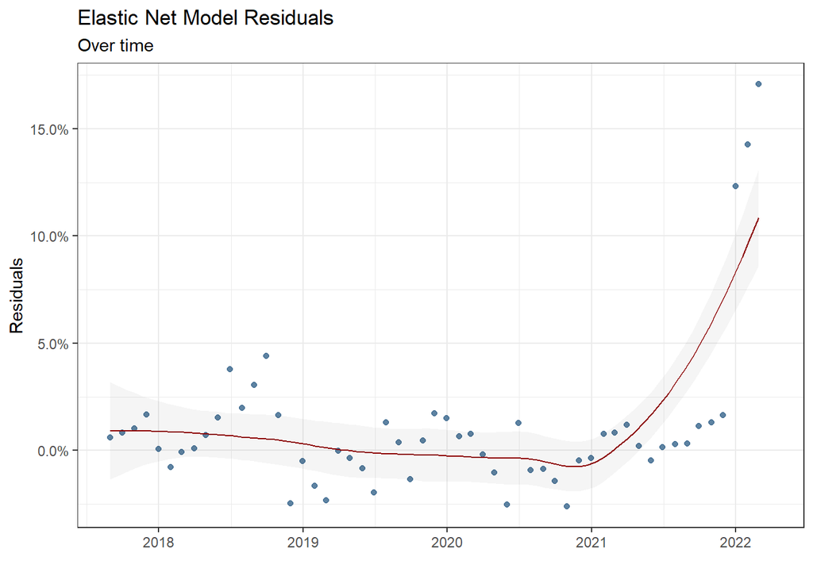

```r
lasso_preds %>%
  mutate(Residual = CPI - pred) %>%
  ggplot(aes(x = Date, y = Residual))+
  geom_point(size = 1.5, alpha = 0.8, color = "steelblue4")+
  geom_ribbon(stat='smooth', se=TRUE, alpha=0.05) +
  geom_line(stat='smooth', alpha=1, color = "darkred")+
  theme_bw() +
  labs(y = "Residuals",
       x = "",
       title = "Elastic Net Model Residuals",
       subtitle = "Over time")+
  scale_y_continuous(labels = scales::percent)
```

The third plot shows the model residuals over time. Notice that the model performance improves over time (until 2021), the smoothed residual curve gets closer to zero, and the frequency of outliers decreases. However, since 2021, the model performance has started to deteriorate caused by economic shocks. A different dynamic that cannot be taken into account comes into play.

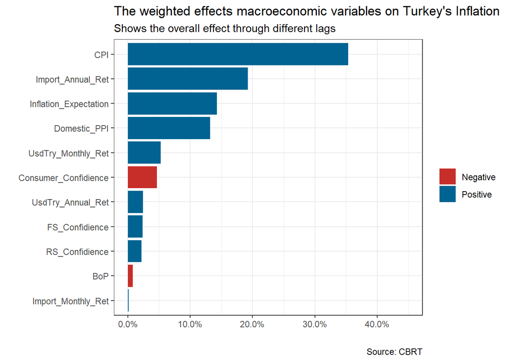

```r
var_names <- coef(elastic_net_fit$finalModel,
                  elastic_net_fit$finalModel$lambdaOpt) %>%
  rownames()

var_values <- coef(elastic_net_fit$finalModel,
                   elastic_net_fit$finalModel$lambdaOpt) %>%
  as.numeric()

model_result <- tibble(Variable_Names = var_names,
                       Coefficients = var_values)

model_result %>%
  mutate(Variable = gsub('[[:digit:]]+', '',
                         str_remove(model_result$Variable_Names,
                                    "_Lag"))) %>%
  group_by(Variable) %>%
  summarise(Overall_Effect = sum(Coefficients)) %>%
  filter(!Overall_Effect == 0) %>%
  filter(!Variable == "(Intercept)") %>%
  mutate(If_Positive = ifelse(Overall_Effect >0, "Positive", "Negative")) %>%
  mutate(Sum = sum(abs(Overall_Effect))) %>%
  mutate(Percent_Effect = Overall_Effect / Sum) %>%
  ggplot(aes(x = reorder(Variable, abs(Overall_Effect)), y = abs(Percent_Effect), fill = If_Positive))+
  geom_col(alpha = 3)+
  scale_y_continuous(labels = scales::percent)+
  expand_limits(y = c(0,0.45))+
  coord_flip() +
  labs(y = "",
       x = "",
       fill = "",
       title = "The weighted effects macroeconomic variables on Turkey's Inflation",
       subtitle = "Shows the overall effect through different lags",
       caption = "Source: CBRT")+
  theme_bw()+
  scale_fill_wsj()
```

The final plot shows the weighted effect of macroeconomic variables on Turkey’s inflation. Notice two things. First, the values on the x-axis are not coefficients, but the share of each variable in total effect. Second, it shows the overall impact coming through multiple lags.

The findings are consistent with macroeconomic facts. First, the highest share of CPI confirms the well-known “inertia’ phenomenon in inflation.”Inertia" refers to a situation in which prices in the whole economy adjust with the change in the price index. Therefore, it creates a self-sustaining loop. Secondly, the effect of annual changes in import prices follows CPI. It is known as one of the most significant determinants of Turkey’s inflation. Finally, inflation expectations have the third-highest effect. Theoretically, economic agents process all the information available constitutes expectation about the future and maximizes their utility. When all economic agents believe that future inflation rises, it turns into a self-fulfilling prophecy. Therefore, it shows how important is to shape the beliefs and expectations of different agents in the economy.